# Thema 8 · Toetsgevoel & *z*-toets

Deel 5 — Toetsen · *de bakker*

# Twee soorten vragen

In thema 7 vroegen we: *wat is $\mu_x$?* — antwoord een getal, met een betrouwbaarheidsinterval eromheen. Nu draaien we de vraag om: *ís $\mu_x$ gelijk aan een bepaalde waarde?* — en dat wordt geen hard ja of nee, maar een **beslissing onder onzekerheid**: houden we die waarde nog vol, of wordt onze data te vreemd? Dat tweede is **toetsen**.

Lees dus altijd eerst: vragen ze om een **getal** (→ interval) of om een **ja/nee** (→ toets)?

**OpmerkingDe egels — toetsen we slimheid**

Pienterheid $\sim N(\mu_x, \sigma_x)$ met $\sigma_x = 15$. We vermoeden dat egels pienterder zijn dan de norm van 100. We nemen een steekproef van $n = 25$ en vinden $\bar{x} = 106$. Vraag: is dat genoeg om te zeggen dat egels écht boven de 100 zitten, of is het toeval?

# $H_0$, $H_1$ en de bakker

We zetten twee hypothesen op:

- **$H_0$** (de nulhypothese): *er is niets aan de hand* — egels zijn gewoon 100. $\mu_x = 100$.
- **$H_1$** (de alternatieve): *er is wél iets* — egels zijn pienterder. $\mu_x > 100$ (rechtszijdig).

We toetsen **altijd de nulhypothese** ($H_0$), nooit de alternatieve — we kijken hoe verbaasd onze data ons maakt onder de aanname dat er niks aan de hand is. Waarom dat zo gaat? Het bakker-verhaal:

**TipDe bakker**

Aan de overkant zat een bakker — al twintig jaar dezelfde, je liep er als kind al naar binnen. Maar je bent er een tijd niet meer geweest; misschien is er nu een fietsenwinkel, misschien een coffeeshop, misschien hangt er nog steeds een rij van zaterdagochtend voor de croissantjes. Je weet het niet. Je móét gaan kijken — maar je mag niet kiezen wat je pakt.

Ik stuur je geblinddoekt, met een knijper op je neus, de winkel in en zeg: *“doe maar wat”* (= een steekproef nemen — de populatie zelf, wat er écht zit, zie je nooit). Pak iets, voel eraan, neem het mee naar buiten.

Onder $H_0$ — *het is nog steeds de bakker* — wat verwacht je in je handen? **Brood**. Hard, vers, knapperig. Of een croissantje, een koekje, een puddingbroodje — passen ook prima binnen ‘bakker’. Daar schrik je niet van; dat is wat een bakker doet.

Maar nu voel je een **fiets**. Een echte fiets, stuur en al. Kan dat? In theorie wel: misschien zit er een actie en krijgt de miljoenste klant een fiets. Maar de kans dat jij net die ene bent — zó klein dat je **schrikt**. En in die schrik zit de hele toets: de kans op “dit of nog gekker”, gegeven dat de nulhypothese waar is, was zo piepklein dat je het idee *“het is nog steeds de bakker”* niet meer kunt vasthouden. Je verwerpt de nulhypothese — de bakker is weg.

**When p is low, $H_0$ must go.** (Niet omdat $H_0$ onmogelijk is — maar omdat de data, *áls* $H_0$ waar zou zijn, té uitzonderlijk werden om dat idee nog vast te houden.)

Dat is **conditioneel denken**, de kern van het hele vak: *stel dat $H_0$ waar is — hoe verbaasd ben ik dan over wat ik vond?*

# $\alpha$ = hoeveel vals alarm je accepteert

Hoe klein moet die kans zijn voor je schrikt? Die grens spreken we van tevoren af: **$\alpha$**, meestal 5%. Wat betekent dat eigenlijk?

**TipDe rechter — streng versus los**

$H_0$ = onschuldig, $H_1$ = schuldig. Een **type-I-fout** is iemand veroordelen die onschuldig is. Stel je twee rechters. De ene wil bijna niemand onterecht veroordelen en eist véél bewijs — **streng**, weinig vals alarm. De andere accepteert meer risico en veroordeelt al bij minder bewijs — **losser**, meer vals alarm (meer onschuldigen vast).

$\alpha$ is precies dat percentage: **hoeveel onschuldigen je accepteert toch te veroordelen.** Bij $\alpha = .05$ zeggen we: we vinden het oké dat, als $H_0$ écht waar is, we de nulhypothese tóch in 5% van de steekproeven verwerpen. Het is een *afgesproken risico op vals alarm* — geen meetfout.

# De snelle weg (3 regels, overzicht)

Voor wie het patroon al kent — zo zit het toetsje in elkaar:

1. **Standaardiseer:** $z = \dfrac{\bar{x} - \mu_0}{\sigma_{\bar{x}}} = \dfrac{106 - 100}{3} = 2{,}00$.
2. **Zoek de kans:** $p = .0228$ (rechterstaart bij $z = 2{,}00$). $p < .05$.
3. **Beslis:** verwerp de nulhypothese.

**Conclusie:** egels scoren significant boven 100 — de pienterheid van egels ligt hoger dan de norm. Klaar.

# De lange weg — het toets-stappenplan

Drie regels klinkt simpel, maar onder de motorkap zitten acht stapjes die je elke toets opnieuw doorloopt. Schrijf ze altijd uit; het ritueel bewaakt je tegen onzin.

**Stap 1 · Onderzoeksvraag.** Zijn egels pienterder dan de norm van 100?

**Stap 2 · Hypothesen.** $H_0: \mu_x = 100$ (geen verschil). $H_1: \mu_x > 100$ (rechtszijdig — we vermoeden hoger, niet anders).

**Stap 3 · Toetskeuze.** Eén gemiddelde, $\sigma_x$ bekend → **z-toets**.

**Stap 4 · Laat $H_0$ waar zijn en teken de steekproevenverdeling.** Onder $H_0$ ligt het centrum op $\mu_0 = 100$ met standaardfout $\sigma_{\bar{x}} = 15/\sqrt{25} = 3$. De rechterstaart van 5% (= $\alpha$) is het **verwerpingsgebied**:

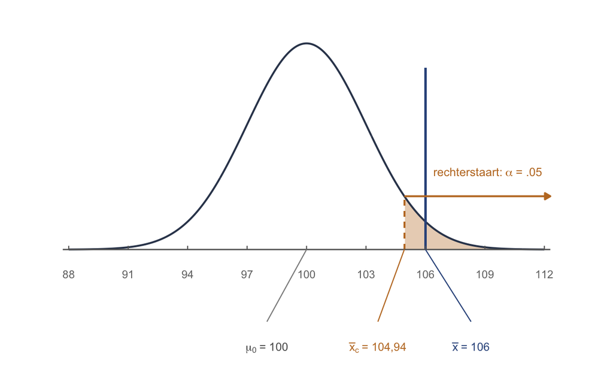

Figuur 1: De steekproevenverdeling onder H0 (mu0 = 100, standaardfout 3). De oranje staart rechts is het verwerpingsgebied (alpha = 5%); de grens ligt op de kritieke waarde x̄c = 104,94. De gevonden steekproef x̄ = 106 (blauwe lijn) valt in het verwerpingsgebied → verwerpen.

**Stap 5 · Toetsingsgrootheid.** Standaardiseer onze steekproef: $z = \dfrac{\bar{x} - \mu_0}{\sigma_{\bar{x}}} = \dfrac{106 - 100}{3} = 2{,}00$. Twee lineaaltjes boven de verwachting.

**Stap 6 · p-waarde óf kritieke waarde** — twee paden, zelfde antwoord. Zie hieronder.

**Stap 7 · Statistische beslissing.** Beide paden zeggen hetzelfde: verwerp $H_0$.

**Stap 8 · Inhoudelijke conclusie.** *Wat verschilt er, en op welke Y?* — hier is Y de pienterheid en de groep de egels: **bij egels ligt de gemiddelde pienterheid significant boven de norm van 100** ($z = 2{,}00$, $p = .023$, eenzijdig, $\alpha = .05$). (Een *verschil* met de norm — geen causaal effect; we hebben niks gemanipuleerd.)

## Stap 6a — Methode 1: de p-waarde ($x \to z \to p$)

De gewone manier (ook wat SPSS doet): standaardiseer en zoek de kans op. Bij $z = 2{,}00$ is de rechterstaart $p = .0228$. Dat is kleiner dan $\alpha = .05$ → **verwerp de nulhypothese**. De kans om 106 of hoger te vinden als egels gewoon 100 zijn, is maar 2,3% — dat is de fiets in de bakker.

## Stap 6b — Methode 2: de kritieke waarde ($p \to z \to x$)

Nu andersom: bepaal vóór je de steekproef ziet vanaf welke grens je verwerpt. Die grens — de **kritieke waarde** $\bar{x}_c$ — bouwen we op in drie stapjes, elk eentje moeilijker:

**TipOpklimmen — van wat je weet naar de kritieke waarde**

**(a) 50/50 — geen tabel nodig.** Als $H_0$ waar is, hoe vaak vind je een steekproefgemiddelde boven $\mu_0 = 100$? **50%** (en 50% eronder). Pure symmetrie — die zoek je niet op, die wéét je.

**(b) 75/25 — nu wél de tabel.** Boven welke grens liggen de 25% hóógste steekproefgemiddelden? Bij 25% boven hoort $z = 0{,}674$, dus grens $= 100 + 0{,}674 \cdot 3 = 102{,}02$. Pure $p \to z \to x$ — nog geen alpha, geen verwerpen.

**(c) 95/5 — pas hier komt $\alpha$.** Maak die bovenkant nu 5% (= $\alpha$). Bij 5% boven hoort $z = 1{,}645$, dus $\bar{x}_c = 100 + 1{,}645 \cdot 3 = 104{,}94$. Zelfde som, nieuwe naam: déze grens is de **kritieke waarde**, en die 5% heet $\alpha$.

Onze steekproef: $\bar{x} = 106$ ligt **boven** $\bar{x}_c = 104{,}94$, dus in het **verwerpingsgebied** → **verwerp de nulhypothese**. Beide methoden geven dezelfde conclusie — natuurlijk, het is dezelfde wandeling, andere kant op.

**BelangrijkDe val: 1,645 of 1,96?**

Studenten grijpen reflexmatig naar **1,96** — want “we kijken altijd naar 95%”. Maar dat is 95% in het **midden** (tweezijdig) → dan zit er 2,5% in *één* staart → 1,96. Bij een **eenzijdige** toets willen we 5% in één staart → **1,645**. **Teken het eerst** (zoals de figuur hierboven), dan zie je het verschil meteen.

*Twee routes, zelfde antwoord:* het college leest de bijbehorende $z^*$ af in de procenten-rij van de t-tabel; wij vragen “welke $z$ hoort bij 5% in één staart?”. Allebei kom je op 1,645 uit — zo doet het college het, zo doe ik het.

# Eén- of tweezijdig?

Onze $H_1$ was $\mu_x > 100$ (rechtszijdig) — we keken alleen naar de rechterstaart. Bij een **tweezijdige** $H_1$ ($\mu_x \neq 100$) weet je de kant niet, dus kijk je naar **beide** staarten:

**TipPippi Langkous**

Tweezijdig = twee staarten. De p-waarde keer **2** (Pippi: twee staarten), en de kritieke $z^*$ wordt 1,96 (2,5% per kant). Bij ons tweezijdig: $p = 2 \times .0228 = .0456$ — nog steeds $< .05$, dus ook dan verwerpen.

# Beslissing is niet hetzelfde als werkelijkheid

Of je nu verwerpt of niet — je kunt het mis hebben, want de werkelijkheid (kent alleen God) is onbekend:

- **Type-I-fout:** de nulhypothese verwerpen terwijl $H_0$ waar is (vals alarm). De kans hierop is $\alpha$.
- **Type-II-fout:** de nulhypothese níét verwerpen terwijl $H_1$ waar is (gemiste vondst).

Trek **beslissing** en **werkelijkheid** altijd los van elkaar. (De kans om een echt effect óók echt te vangen — het tegenovergestelde van een type-II-fout — heet de *power*; daar gaat thema 10 over.)

# Toets en interval zijn elkaars spiegelbeeld

Herinner je T7: bij $n = 9$, $\bar{x} = 108$ vonden we het 95%-interval $[98{,}2\,;\,117{,}8]$, en 100 lag erin. Dat is precies hetzelfde als een **tweezijdige toets met hetzelfde $\alpha = .05$** (let op: alléén dan): ligt $\mu_0$ binnen het interval → niet verwerpen; erbuiten → verwerpen. CI en toets zijn in elkaar vertaalbaar — het verschil is alleen wat je in het midden zet: bij een interval het steekproefgemiddelde, bij een toets de waarde uit $H_0$.

**TipWelke kant op? (de richtings-engine, lineaaltje = σ_x̄)**

- **Toets (p-waarde):** je hebt $\bar{x}$, je zoekt een kans → $\bar{x} \to z \to p$.
- **Kritieke waarde:** je hebt $\alpha$ (een kans), je zoekt de grens → $\alpha \to z \to \bar{x}_c$.

Steeds hetzelfde fietsje, met de standaardfout $\sigma_{\bar{x}}$ als lineaaltje.

# Oefenen

**OpmerkingT8.1 — Een z-toets, beide methoden**

Egels, $\sigma_x = 15$, $H_0: \mu_x = 100$, $H_1: \mu_x > 100$, $\alpha = .05$. Een steekproef van $n = 9$ geeft $\bar{x} = 109$.

1. Doe de p-waarde-methode.
2. Doe de kritieke-waarde-methode.
3. Conclusie?

**OpgeletAntwoord T8.1**

$\sigma_{\bar{x}} = 15/\sqrt{9} = 5$.

**(a)** $z = \dfrac{109 - 100}{5} = 1{,}80$. Rechterstaart bij $z = 1{,}80$: $p = .0359$. Dat is $< .05$ → verwerp de nulhypothese.

**(b)** $\bar{x}_c = 100 + 1{,}645 \cdot 5 = 108{,}23$. De gevonden $109 > 108{,}23$ → in het verwerpingsgebied → verwerp de nulhypothese.

**(c)** Beide: **verwerp $H_0$** — de gemiddelde pienterheid van egels ligt significant boven 100 ($z = 1{,}80$, $p = .036$, eenzijdig, $\alpha = .05$). Dit verschil is generaliseerbaar naar de populatie.

**OpmerkingT8.2 — Eén- vs tweezijdig**

Stel de toets uit T8.1 was **tweezijdig** ($H_1: \mu_x \neq 100$) geweest.

1. Welke $z^*$ hoort daar bij $\alpha = .05$?
2. Wat wordt de p-waarde, en verandert de conclusie?

**OpgeletAntwoord T8.2**

**(a)** Tweezijdig, 95% in het midden → 2,5% per staart → $z^* = 1{,}96$.

**(b)** Pippi: $p = 2 \times .0359 = .0718$. Dat is **niet** meer $< .05$ → nu *niet* verwerpen. Een mooi grensgeval: eenzijdig wél, tweezijdig net niet. Wie de richting van $H_1$ van tevoren goed onderbouwt, mag eenzijdig — maar besef dat het verschil maakt.

# Wat blijft liggen

Hier deden we alsof we $\sigma_x$ kennen. In de echte wereld nooit — dan schat je ’m met $s_x$ en gebruik je de $t$-verdeling (thema 9). En in thema 10 maken we het toetsgevoel compleet met de **power**: niet alleen “verwerp ik?”, maar “hoe goed vang ik een echt effect?”.

# Tot slot

Toetsen is conditioneel denken in maat en getal: stel de nulhypothese waar, en kijk hoe verbaasd je bent. De bakker geeft het gevoel, de p-waarde en de kritieke waarde geven het getal, en $\alpha$ is de grens die je zelf afspreekt. Drie regels voor de snelle weg, acht stappen voor de lange weg met figuur — beide leiden naar dezelfde beslissing.

*Werkboek OZP 1 · Thema 8, versie 0.2 (handrekenen & theorie; SPSS later). Doorlopend voorbeeld: de egels.*

Terug naar boven